# CUL3 KD - Nia Teerikorpi NPC.RM

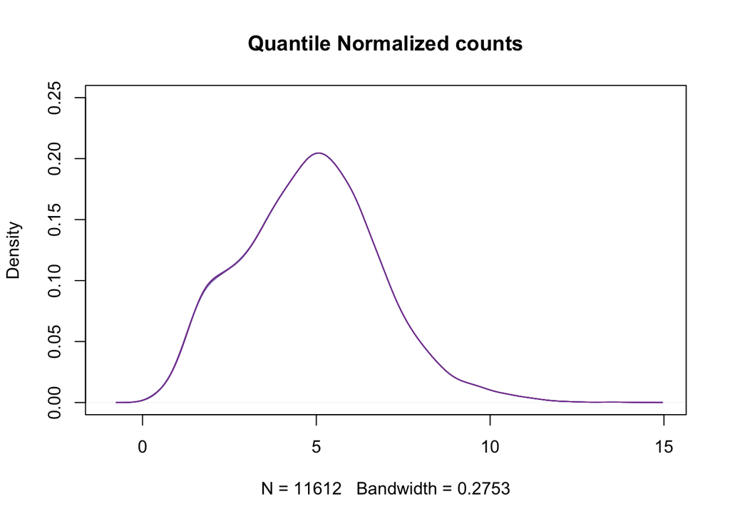

```r
amanda.plot.density(log.norm_counts, title="Quantile Normalized counts", my.ylim = c(0,0.25), my.xlim = c(-1,15))
```

- Explore what data looks like with PCAs

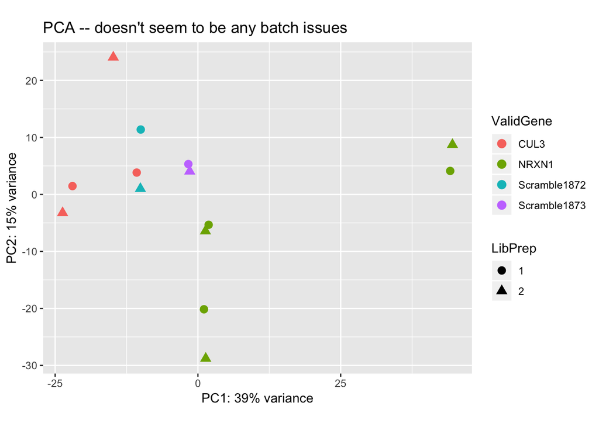

```r
pca <- prcomp(t(log.norm_counts), center = T)
percentVar <- pca$sdev^2/sum(pca$sdev^2)
d <- data.frame(PC1 = pca$x[, 1], PC2 = pca$x[, 2])
e <- merge(d, metadata, by="row.names")
e$LibPrep <- as.factor(e$LibPrep)

ggplot(data = e,
       aes_string(x = "PC1", y = "PC2", color = "ValidGene", shape="LibPrep")) +
  geom_point(size = 3) + coord_fixed() +
  xlab(paste0("PC1: ", round(percentVar[1] * 100), "% variance")) +
  ylab(paste0("PC2: ", round(percentVar[2] * 100), "% variance")) +
  ggtitle("PCA -- doesn't seem to be any batch issues")
```

- Is the separation because of the different guides?

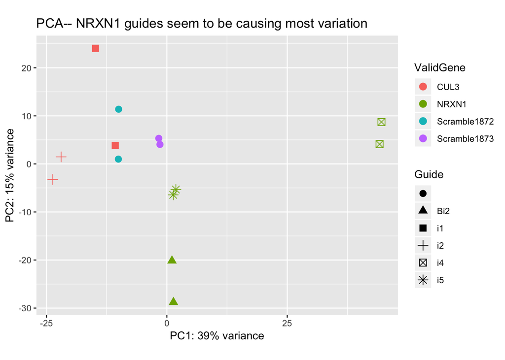

```r
ggplot(data = e,
       aes_string(x = "PC1", y = "PC2", color = "ValidGene", shape="Guide")) +
  geom_point(size = 3) + coord_fixed() +
  xlab(paste0("PC1: ", round(percentVar[1] * 100), "% variance")) +
  ylab(paste0("PC2: ", round(percentVar[2] * 100), "% variance")) +
  ggtitle("PCA-- NRXN1 guides seem to be causing most variation")
```

- First, lets quickly check if it looks like the KD was successful

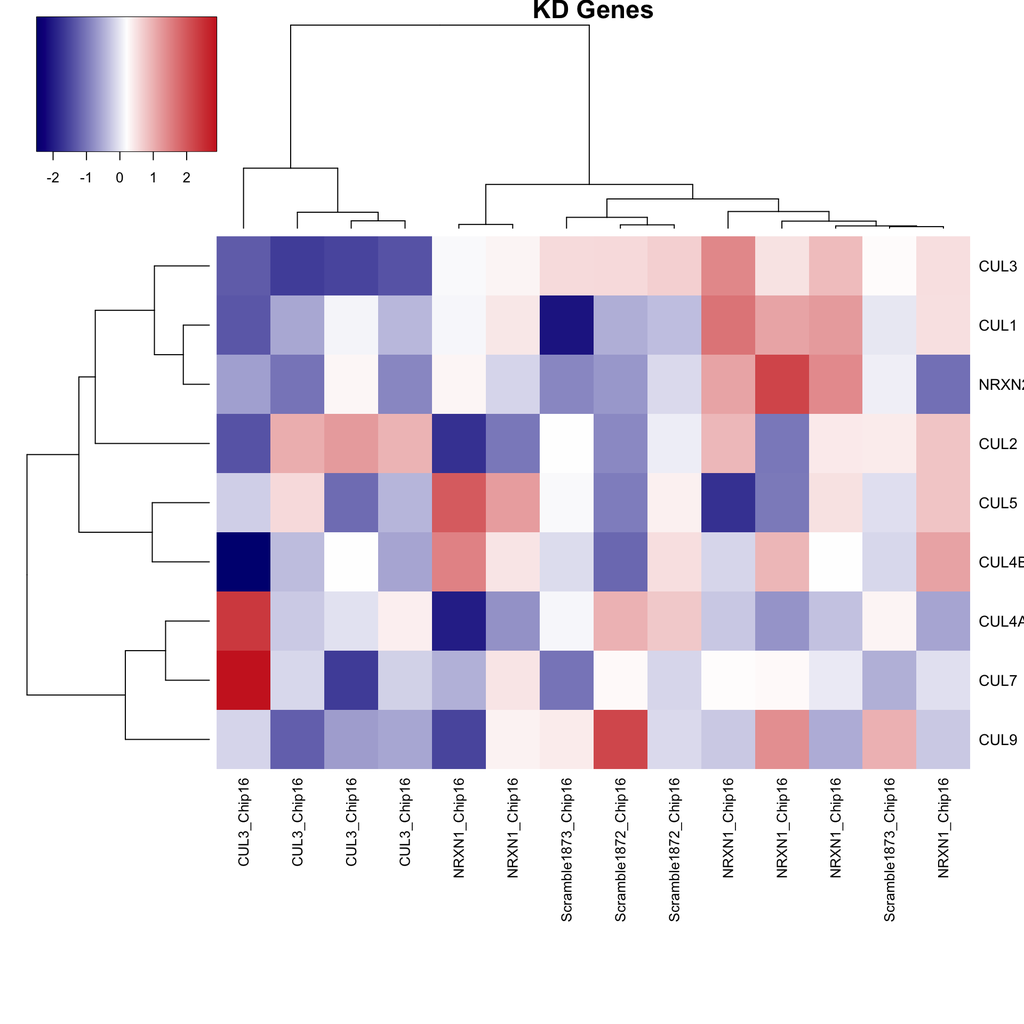

- You’ll notice NRXN1 doesnt come up on this list. It was actually removed for low expression in these cells. For the purpose of the demo we will only go forward with the CUL3 DEX.

[figure not shown]

- save normalized counts for any other follow up analyses (coexpression for example) to output file

```r
write.csv(as.data.frame(norm_counts), file=paste0(out_dir, "/00_norm_counts.csv"))
```

### Step 4: Differential Gene Expression and GO analysis

- Collapsing both Scrambles into one control group
- For the purpose of the demo we are going to ignore the different guides here, but if you want to practice later this could be a good exercise.
- DESeq2 takes in the raw counts (not normalized because DESeq2’s model internally corrects for library size, so transformed or normalized values such as counts scaled by library size should not be used as input.)
- https://www.bioconductor.org/packages/devel/bioc/vignettes/DESeq2/inst/doc/DESeq2.html

```r
#First, lets remove the NRXN1 samples
cts <- cts[, !colnames(cts) %in% grep("NRXN1", colnames(cts), value = T)]
metadata <- metadata[!rownames(metadata) %in% grep("NRXN1", rownames(metadata), value = T), ]
```

```r
#Lets create a column thats just the grouping we exactly want so we can visualize this
metadata$Condition <- metadata$ValidGene #Create a duplicate column
metadata$Condition <- as.character(metadata$Condition)
metadata[metadata$ValidGene %in% c("Scramble1872", "Scramble1873"), ]$Condition <- "Control"
metadata[,c("Condition","ValidGene")]
```

```
##                                                 Condition    ValidGene
## WTC11_dCas9_NPC.RM_ip9_Scramble1872_Rep2_Chip16   Control Scramble1872
## WTC11_dCas9_NPC.RM_ip9_Scramble1873_Rep2_Chip16   Control Scramble1873
## WTC11_dCas9_NPC.RM_ip9_CUL3i1_Rep2_Chip16            CUL3         CUL3
## WTC11_dCas9_NPC.RM_ip9_CUL3i2_Rep2_Chip16            CUL3         CUL3
## WTC11_dCas9_NPC.RM_ip9_Scramble1872_Rep1_Chip16   Control Scramble1872
## WTC11_dCas9_NPC.RM_ip9_Scramble1873_Rep1_Chip16   Control Scramble1873
## WTC11_dCas9_NPC.RM_ip9_CUL3i1_Rep1_Chip16            CUL3         CUL3
## WTC11_dCas9_NPC.RM_ip9_CUL3i2_Rep1_Chip16            CUL3         CUL3
```

```r
#Set what the reference level is -- tell the computer which is your control group
metadata$Condition <- as.factor(metadata$Condition)
metadata$Condition <- relevel(metadata$Condition, ref = "Control")
```

```r
suppressPackageStartupMessages(library(DESeq2))
#What design should we use?
#Linear models and generalized linear models incorporate a model matrix which is one of the terms for DESeq

model.matrix(~ Condition, metadata)
```

```
##                                                 (Intercept) ConditionCUL3
## WTC11_dCas9_NPC.RM_ip9_Scramble1872_Rep2_Chip16           1             0
## WTC11_dCas9_NPC.RM_ip9_Scramble1873_Rep2_Chip16           1             0
## WTC11_dCas9_NPC.RM_ip9_CUL3i1_Rep2_Chip16                 1             1
## WTC11_dCas9_NPC.RM_ip9_CUL3i2_Rep2_Chip16                 1             1
## WTC11_dCas9_NPC.RM_ip9_Scramble1872_Rep1_Chip16           1             0
## WTC11_dCas9_NPC.RM_ip9_Scramble1873_Rep1_Chip16           1             0
## WTC11_dCas9_NPC.RM_ip9_CUL3i1_Rep1_Chip16                 1             1
## WTC11_dCas9_NPC.RM_ip9_CUL3i2_Rep1_Chip16                 1             1
## attr(,"assign")
## [1] 0 1
## attr(,"contrasts")
## attr(,"contrasts")$Condition
## [1] "contr.treatment"
```

```r
dds <- DESeqDataSetFromMatrix(countData = cts, colData = metadata, design= ~Condition) #create object for DESeq
dds <- DESeq(dds) #run deseq2 model
dds
```

```
## class: DESeqDataSet
## dim: 11612 8
## metadata(1): version
## assays(4): counts mu H cooks
## rownames(11612): SEC24B.AS1 A2M ... TVP23B RPL23AP82.1
## rowData names(22): baseMean baseVar ... deviance maxCooks
## colnames(8): WTC11_dCas9_NPC.RM_ip9_Scramble1872_Rep2_Chip16
##   WTC11_dCas9_NPC.RM_ip9_Scramble1873_Rep2_Chip16 ...
##   WTC11_dCas9_NPC.RM_ip9_CUL3i1_Rep1_Chip16
##   WTC11_dCas9_NPC.RM_ip9_CUL3i2_Rep1_Chip16
## colData names(29): RunName RunInfo ... Condition sizeFactor
```

```r
resultsNames(dds)
```

```
## [1] "Intercept"                 "Condition_CUL3_vs_Control"
```

- Visualize the dispersion estimates (plots the per-gene dispersion estimates together with the fitted mean-dispersion relationship)

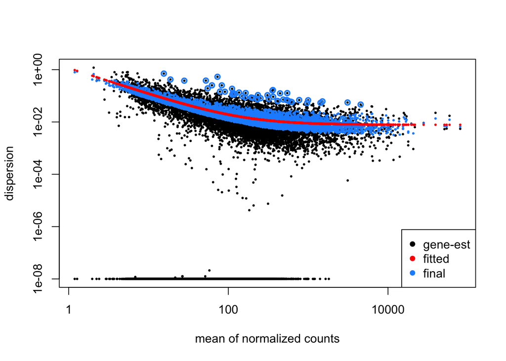

```r
plotDispEsts(dds)
```

```r
#Generate results tables which extracts a results table with log2 fold changes, p values and adjusted p values
res <- results(dds, name="Condition_CUL3_vs_Control")
#This is the standard call, but you can pass it different model types. The one below is what I typically use


res_lfcShrink <- lfcShrink(dds, coef="Condition_CUL3_vs_Control", type="apeglm")
```

```
## using 'apeglm' for LFC shrinkage. If used in published research, please cite:
##     Zhu, A., Ibrahim, J.G., Love, M.I. (2018) Heavy-tailed prior distributions for
##     sequence count data: removing the noise and preserving large differences.
##     Bioinformatics. https://doi.org/10.1093/bioinformatics/bty895
```

```r
#This model is one I particularly like using because it incorporates a logFC shrinkage meaning that genes with low counts logFC not have inflated fold changes

#Now we can compare the two if you want
summary(res)
```

```
##
## out of 11612 with nonzero total read count
## adjusted p-value < 0.1
## LFC > 0 (up)       : 151, 1.3%
## LFC < 0 (down)     : 57, 0.49%
## outliers [1]       : 0, 0%
## low counts [2]     : 1351, 12%
## (mean count < 17)
## [1] see 'cooksCutoff' argument of ?results
## [2] see 'independentFiltering' argument of ?results
```

```r
summary(res_lfcShrink)
```

```
##
## out of 11612 with nonzero total read count
## adjusted p-value < 0.1
## LFC > 0 (up)       : 151, 1.3%
## LFC < 0 (down)     : 57, 0.49%
## outliers [1]       : 0, 0%
## low counts [2]     : 1351, 12%
## (mean count < 17)
## [1] see 'cooksCutoff' argument of ?results
## [2] see 'independentFiltering' argument of ?results
```

```r
#Significance thresholds will be the same because apeglm only changes the fold changes
```

- We can visualize this as well

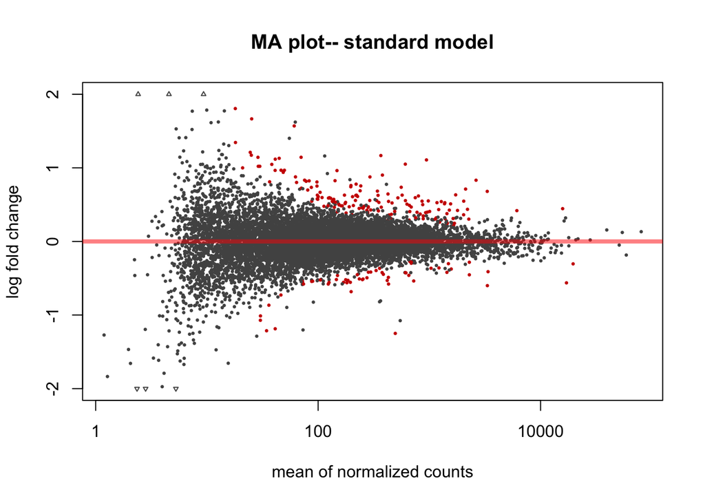

```r
plotMA(res, ylim=c(-2,2), main="MA plot-- standard model")
```

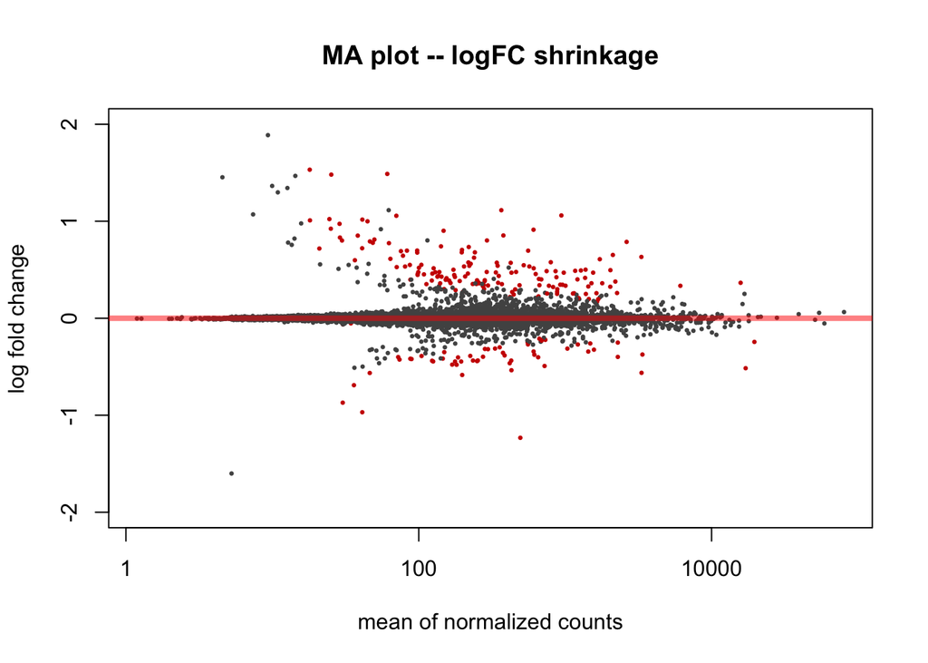

```r
plotMA(res_lfcShrink, ylim=c(-2,2), main = "MA plot -- logFC shrinkage")
```

- Order by adjusted pvalue

```r
resOrdered <- res_lfcShrink[order(res_lfcShrink$padj),]
```

- How many adjusted p-values were less than 0.05?

```r
sum(res$padj < 0.05, na.rm=TRUE)
```

```
## [1] 146
```

```r
resSig <- subset(resOrdered, padj < 0.05)
```

- Output your complete dataframe as well as only the significantly DE genes

```r
write.csv(as.data.frame(resOrdered), file=paste0(out_dir, "01_CUL3_results.csv"))
write.csv(as.data.frame(resSig), file=paste0(out_dir, "02_CUL3_results_DEX.csv"))
```

### Step 5: Lets look at the results!

- First, lets create a heatmap of only the DEX genes

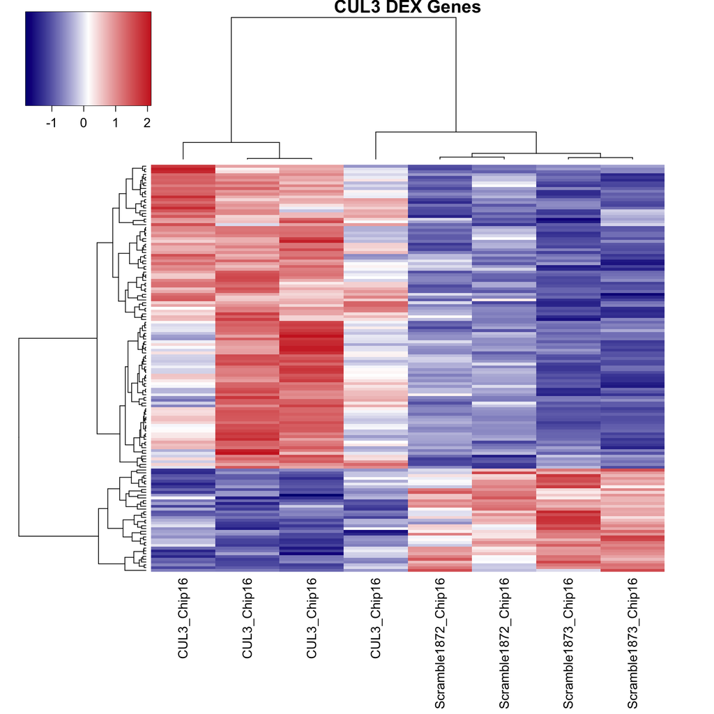

```r
data.to.plot <- data.frame(norm_counts[rownames(norm_counts) %in% rownames(resSig),
                            colnames(norm_counts) %in% rownames(metadata)])
#Lets give better names to the columns so they're not so long
setnames(data.to.plot, old = as.vector(metadata$FullID), new=as.vector(metadata$ShortID))

heatmap3(data.to.plot, labRow = "", main = "CUL3 DEX Genes", margins = c(12,3))
```

# More to come [ after lunch when I finish this :) ]